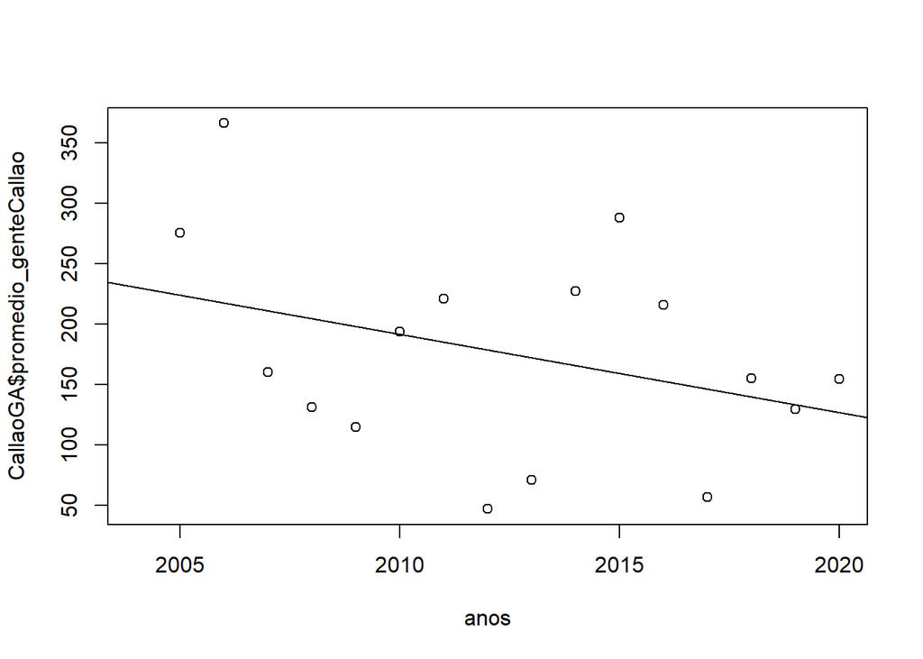

```
##
## Call:
## lm(formula = promedio_genteCusco ~ anos, data = CuscoGA)
##
## Residuals:
##     Min      1Q  Median      3Q     Max
## -285.54 -104.25  -64.32  122.25  370.29
##
## Coefficients:
##               Estimate Std. Error t value Pr(>|t|)
## (Intercept) -60892.373  19901.738  -3.060  0.00849 **
## anos            30.541      9.889   3.088  0.00802 **
## ---
## Signif. codes:  0 '***' 0.001 '**' 0.01 '*' 0.05 '.' 0.1 ' ' 1
##
## Residual standard error: 182.3 on 14 degrees of freedom
##   (1 observation deleted due to missingness)
## Multiple R-squared:  0.4052, Adjusted R-squared:  0.3627
## F-statistic: 9.538 on 1 and 14 DF,  p-value: 0.008015
```

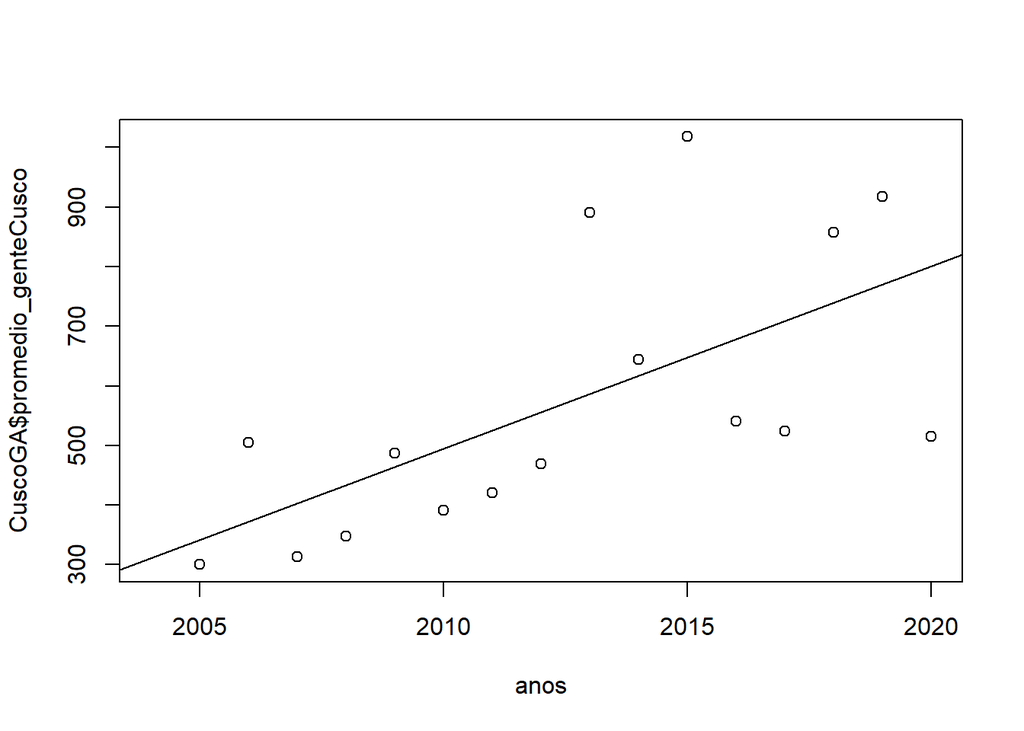

Como se puede observar para Huancavelica, el valor-p es de $0.56$, permitiendo concluir que no se rechaza la $H_0$. En base al valor de $r^2$, se puede concluir que alrededor del $2.5$% de la variabilidad del ingreso promedio mensual se puede explicar con el año de la encuesta.

```
##
## Call:
## lm(formula = promedio_genteHuancavelica ~ anos, data = HuancavelicaGA)
##
## Residuals:
##     Min      1Q  Median      3Q     Max
## -365.14 -132.81    5.54  131.37  248.15
##
## Coefficients:
##              Estimate Std. Error t value Pr(>|t|)
## (Intercept) 12804.899  20512.248   0.624    0.542
## anos           -6.134     10.192  -0.602    0.557
##
## Residual standard error: 187.9 on 14 degrees of freedom
##   (1 observation deleted due to missingness)
## Multiple R-squared:  0.02522,    Adjusted R-squared:  -0.04441
## F-statistic: 0.3622 on 1 and 14 DF,  p-value: 0.5569
```

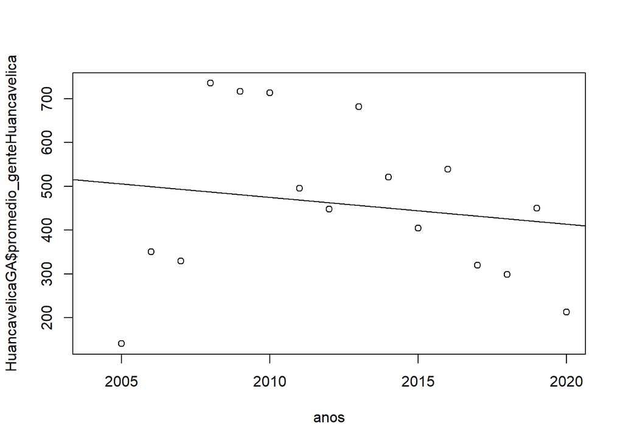

Como se puede observar para Huánuco, el valor-p es de $0.13$, permitiendo concluir que no se rechaza la $H_0$. En base al valor de $r^2$, se puede concluir que alrededor del $15.5$% de la variabilidad del ingreso promedio mensual se puede explicar con el año de la encuesta.

```
##
## Call:
## lm(formula = promedio_genteHuanuco ~ anos, data = HuanucoGA)
##
## Residuals:
##      Min       1Q   Median       3Q      Max
## -139.479  -48.069   -5.339   31.260  108.042
##
## Coefficients:
##              Estimate Std. Error t value Pr(>|t|)
## (Intercept) 12519.613   7653.860   1.636    0.124
## anos           -6.096      3.803  -1.603    0.131
##
## Residual standard error: 70.13 on 14 degrees of freedom
##   (1 observation deleted due to missingness)
## Multiple R-squared:  0.155,  Adjusted R-squared:  0.09469
## F-statistic: 2.569 on 1 and 14 DF,  p-value: 0.1313
```

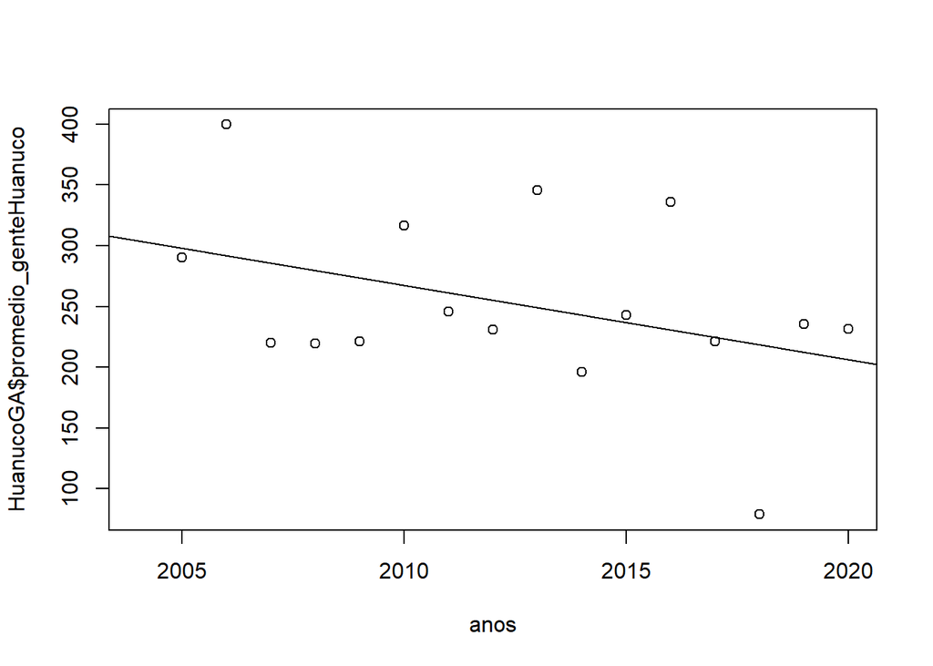

Como se puede observar para Ica, el valor-p es de $0.08$, permitiendo concluir que no se rechaza la $H_0$. En base al valor de $r^2$, se puede concluir que alrededor del $20.4$% de la variabilidad del ingreso promedio mensual se puede explicar con el año de la encuesta.

```
##
## Call:
## lm(formula = promedio_genteIca ~ anos, data = IcaGA)
##
## Residuals:
##     Min      1Q  Median      3Q     Max
## -75.697 -32.836  -7.707  26.127 130.121
##
## Coefficients:
##              Estimate Std. Error t value Pr(>|t|)
## (Intercept) 10948.799   5712.969   1.916   0.0759 .
## anos           -5.369      2.839  -1.891   0.0794 .
## ---
## Signif. codes:  0 '***' 0.001 '**' 0.01 '*' 0.05 '.' 0.1 ' ' 1
##
## Residual standard error: 52.34 on 14 degrees of freedom
##   (1 observation deleted due to missingness)
## Multiple R-squared:  0.2035, Adjusted R-squared:  0.1466
## F-statistic: 3.577 on 1 and 14 DF,  p-value: 0.07944
```

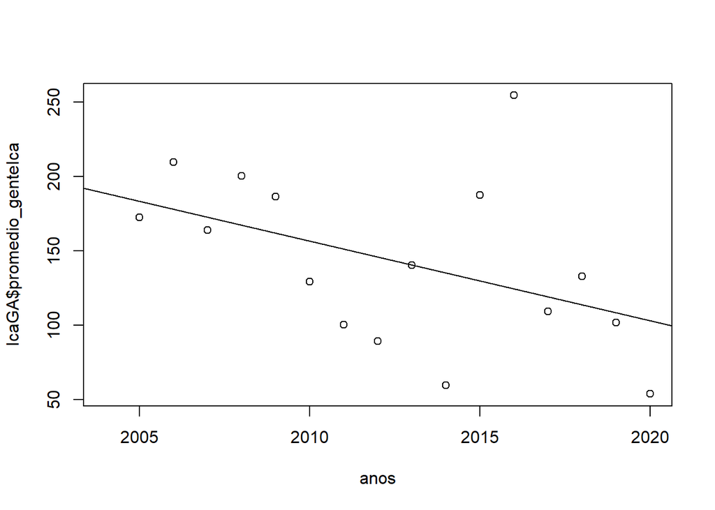

Como se puede observar para Junin, el valor-p es de $0.97$, permitiendo concluir que no se rechaza la $H_0$. En base al valor de $r^2$, se puede concluir que alrededor del $0.008$% de la variabilidad del ingreso promedio mensual se puede explicar con el año de la encuesta.

```
##
## Call:
## lm(formula = promedio_genteJunin ~ anos, data = JuninGA)
##
## Residuals:
##     Min      1Q  Median      3Q     Max
## -72.765 -32.242  -6.023  23.083 108.788
##
## Coefficients:
##               Estimate Std. Error t value Pr(>|t|)
## (Intercept)  314.71301 5335.04403   0.059    0.954
## anos          -0.09062    2.65095  -0.034    0.973
##
## Residual standard error: 48.88 on 14 degrees of freedom
##   (1 observation deleted due to missingness)
## Multiple R-squared:  8.346e-05,  Adjusted R-squared:  -0.07134
## F-statistic: 0.001168 on 1 and 14 DF,  p-value: 0.9732
```

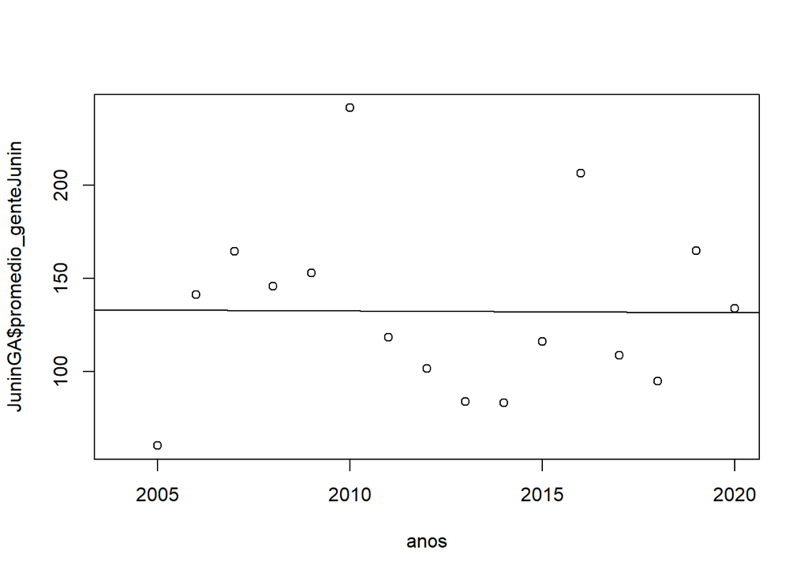

Como se puede observar para La Libertad, el valor-p es de $0.75$, permitiendo concluir que no se rechaza la $H_0$. En base al valor de $r^2$, se puede concluir que alrededor del $0.8$% de la variabilidad del ingreso promedio mensual se puede explicar con el año de la encuesta.

```
##
## Call:
## lm(formula = promedio_genteLalibertad ~ anos, data = LalibertadGA)
##
## Residuals:
##     Min      1Q  Median      3Q     Max
## -74.175 -39.273   9.184  36.339  61.375
##
## Coefficients:
##               Estimate Std. Error t value Pr(>|t|)
## (Intercept) -1607.6445  5291.0358  -0.304    0.766
## anos            0.8595     2.6287   0.327    0.749
##
## Residual standard error: 46.91 on 13 degrees of freedom
##   (2 observations deleted due to missingness)
## Multiple R-squared:  0.008157,   Adjusted R-squared:  -0.06814
## F-statistic: 0.1069 on 1 and 13 DF,  p-value: 0.7489
```

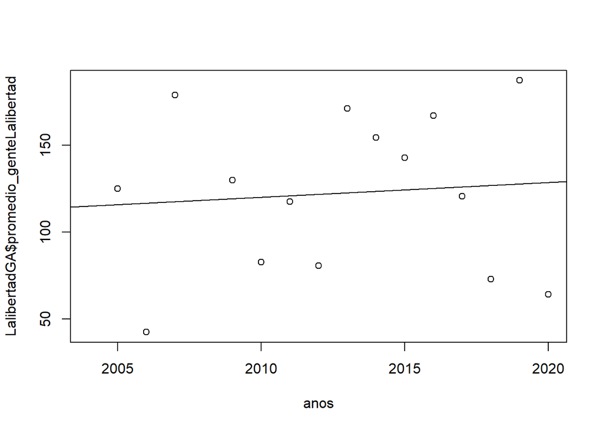

Como se puede observar para Lambayeque, el valor-p es de $0.06$, permitiendo concluir que no se rechaza la $H_0$. En base al valor de $r^2$, se puede concluir que alrededor del $23.6$% de la variabilidad del ingreso promedio mensual se puede explicar con el año de la encuesta.

```
##
## Call:
## lm(formula = promedio_genteLambayeque ~ anos, data = LambayequeGA)
##
## Residuals:
##     Min      1Q  Median      3Q     Max
## -83.169 -26.555  -7.812  35.876  81.064
##
## Coefficients:
##              Estimate Std. Error t value Pr(>|t|)
## (Intercept) 11064.275   5264.732   2.102   0.0542 .
## anos           -5.435      2.616  -2.078   0.0566 .
## ---
## Signif. codes:  0 '***' 0.001 '**' 0.01 '*' 0.05 '.' 0.1 ' ' 1
##
## Residual standard error: 48.24 on 14 degrees of freedom
##   (1 observation deleted due to missingness)
## Multiple R-squared:  0.2357, Adjusted R-squared:  0.1811
## F-statistic: 4.317 on 1 and 14 DF,  p-value: 0.05661
```

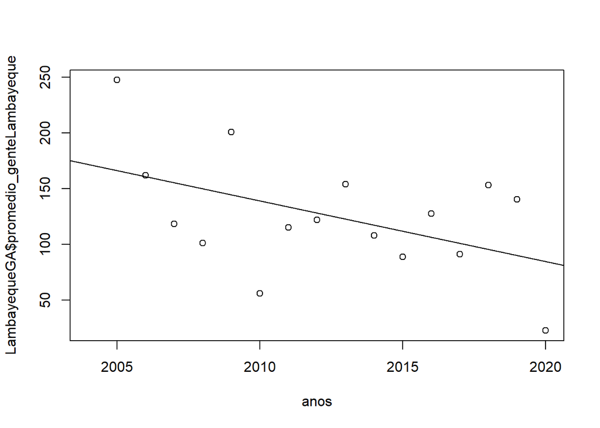

Como se puede observar para Lima, el valor-p es de $0.10$, permitiendo concluir que no se rechaza la $H_0$. En base al valor de $r^2$, se puede concluir que alrededor del $17.7$% de la variabilidad del ingreso promedio mensual se puede explicar con el año de la encuesta.

```
## [1] 17
```

```
##
## Call:
## lm(formula = promedio_genteLima ~ anos, data = LiGA)
##
## Residuals:
##     Min      1Q  Median      3Q     Max
## -105.35  -38.05  -19.79   36.07  175.07
##
## Coefficients:
##              Estimate Std. Error t value Pr(>|t|)
## (Intercept) 14253.508   8084.753   1.763   0.0997 .
## anos           -6.975      4.017  -1.736   0.1045
## ---
## Signif. codes:  0 '***' 0.001 '**' 0.01 '*' 0.05 '.' 0.1 ' ' 1
##
## Residual standard error: 74.07 on 14 degrees of freedom
##   (1 observation deleted due to missingness)
## Multiple R-squared:  0.1772, Adjusted R-squared:  0.1184
## F-statistic: 3.014 on 1 and 14 DF,  p-value: 0.1045
```

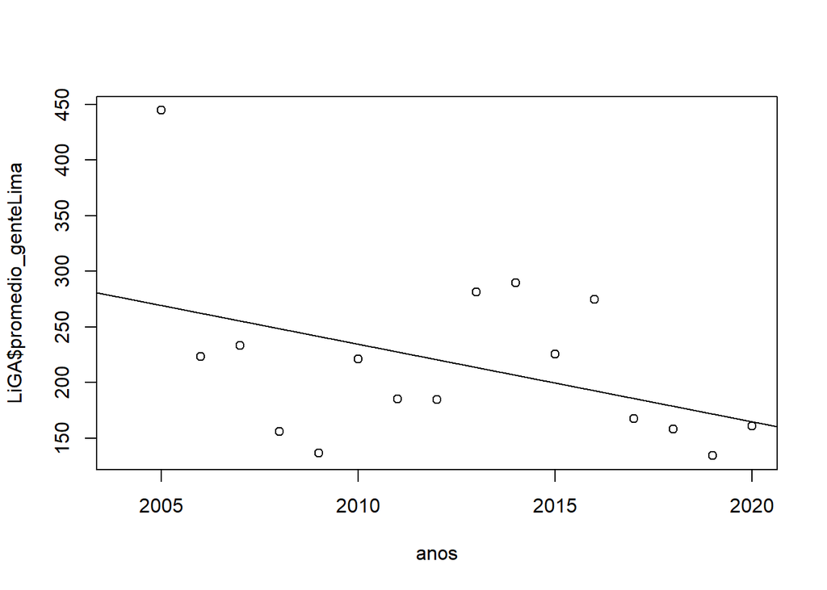

Como se puede observar para Loreto, el valor-p es de $0.48$, permitiendo concluir que no se rechaza la $H_0$. En base al valor de $r^2$, se puede concluir que alrededor del $3.7$% de la variabilidad del ingreso promedio mensual se puede explicar con el año de la encuesta.

```
##
## Call:
## lm(formula = promedio_genteLoreto ~ anos, data = LoretoGA)
##
## Residuals:
##      Min       1Q   Median       3Q      Max
## -104.406  -58.532   -4.952   27.722  170.249
##
## Coefficients:
##             Estimate Std. Error t value Pr(>|t|)
## (Intercept) 6488.149   8642.921   0.751    0.465
## anos          -3.142      4.295  -0.732    0.476
##
## Residual standard error: 79.19 on 14 degrees of freedom
##   (1 observation deleted due to missingness)
## Multiple R-squared:  0.03684,    Adjusted R-squared:  -0.03196
## F-statistic: 0.5354 on 1 and 14 DF,  p-value: 0.4764
```

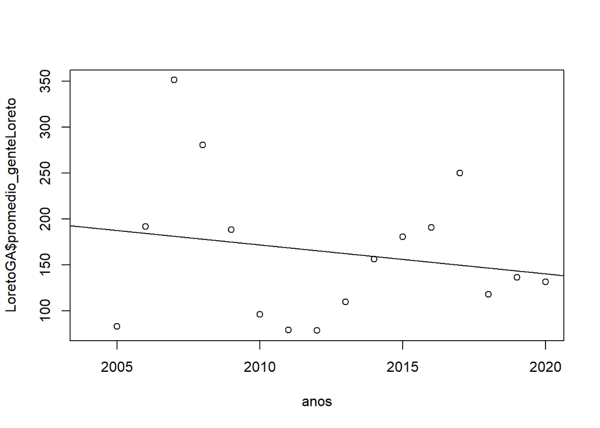

Como se puede observar para Madre de Dios, el valor-p es de $0.09$, permitiendo concluir que no se rechaza la $H_0$. En base al valor de $r^2$, se puede concluir que alrededor del $19.2$% de la variabilidad del ingreso promedio mensual se puede explicar con el año de la encuesta.

```
##
## Call:
## lm(formula = promedio_genteMadredeDios ~ anos, data = MadredeDiosGA)
##
## Residuals:
##    Min     1Q Median     3Q    Max
## -96.37 -55.46 -22.49  34.76 199.00
##
## Coefficients:
##               Estimate Std. Error t value Pr(>|t|)
## (Intercept) -15580.696   8623.254  -1.807   0.0923 .
## anos             7.821      4.285   1.825   0.0894 .
## ---
## Signif. codes:  0 '***' 0.001 '**' 0.01 '*' 0.05 '.' 0.1 ' ' 1
##
## Residual standard error: 79.01 on 14 degrees of freedom
##   (1 observation deleted due to missingness)
## Multiple R-squared:  0.1922, Adjusted R-squared:  0.1345
## F-statistic: 3.332 on 1 and 14 DF,  p-value: 0.08936
```

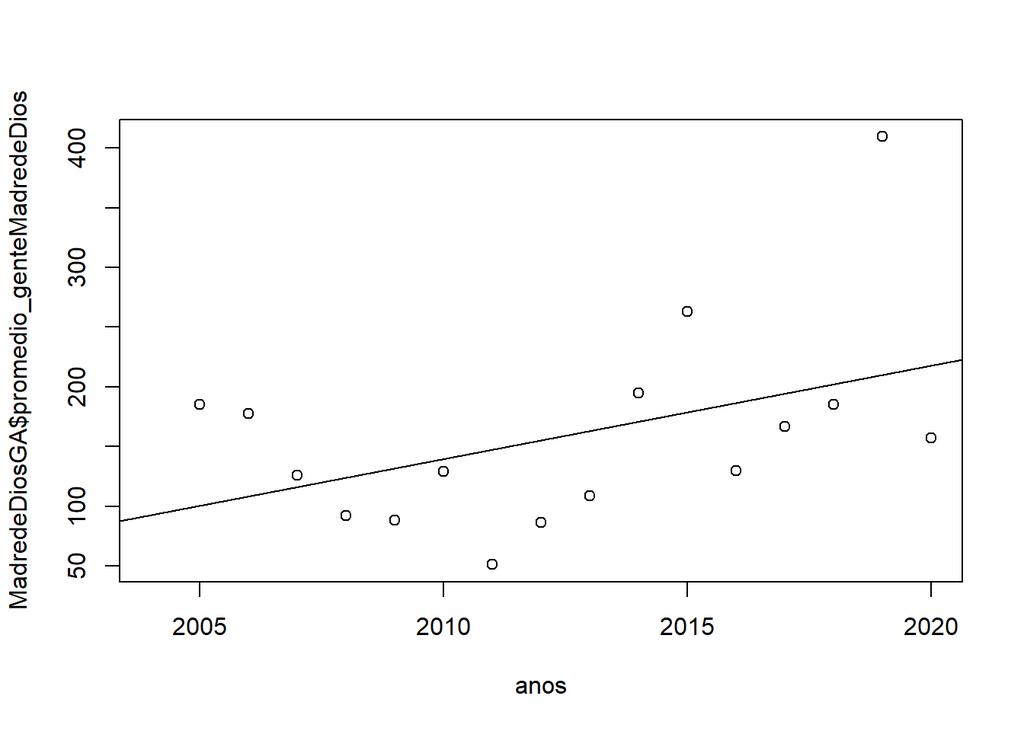

Como se puede observar para Moquegua, el valor-p es de $0.66$, permitiendo concluir que no se rechaza la $H_0$. En base al valor de $r^2$, se puede concluir que alrededor del $1.4$% de la variabilidad del ingreso promedio mensual se puede explicar con el año de la encuesta.

```
##
## Call:
## lm(formula = promedio_genteMoquegua ~ anos, data = MoqueguaGA)
##
## Residuals:
##     Min      1Q  Median      3Q     Max
## -449.85 -216.87    3.26  134.12  458.22
##
## Coefficients:
##               Estimate Std. Error t value Pr(>|t|)
## (Intercept) -11883.857  27693.344  -0.429    0.674
## anos             6.171     13.761   0.448    0.661
##
## Residual standard error: 253.7 on 14 degrees of freedom
##   (1 observation deleted due to missingness)
## Multiple R-squared:  0.01416,    Adjusted R-squared:  -0.05625
## F-statistic: 0.2011 on 1 and 14 DF,  p-value: 0.6607
```

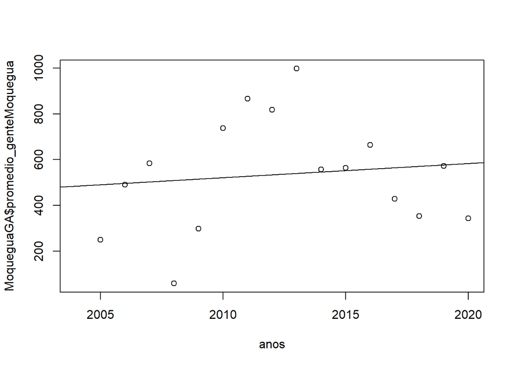

Como se puede observar para Pasco, el valor-p es de $0.52$, permitiendo concluir que no se rechaza la $H_0$. En base al valor de $r^2$, se puede concluir que alrededor del $3$% de la variabilidad del ingreso promedio mensual se puede explicar con el año de la encuesta.

```
##
## Call:
## lm(formula = promedio_gentePasco ~ anos, data = PascoGA)
##
## Residuals:
##     Min      1Q  Median      3Q     Max
## -249.72  -58.38  -25.67   75.78  266.82
##
## Coefficients:
##              Estimate Std. Error t value Pr(>|t|)
## (Intercept)  8820.172  12887.740   0.684    0.505
## anos           -4.242      6.404  -0.662    0.518
##
## Residual standard error: 118.1 on 14 degrees of freedom
##   (1 observation deleted due to missingness)
## Multiple R-squared:  0.03039,    Adjusted R-squared:  -0.03887
## F-statistic: 0.4388 on 1 and 14 DF,  p-value: 0.5184
```

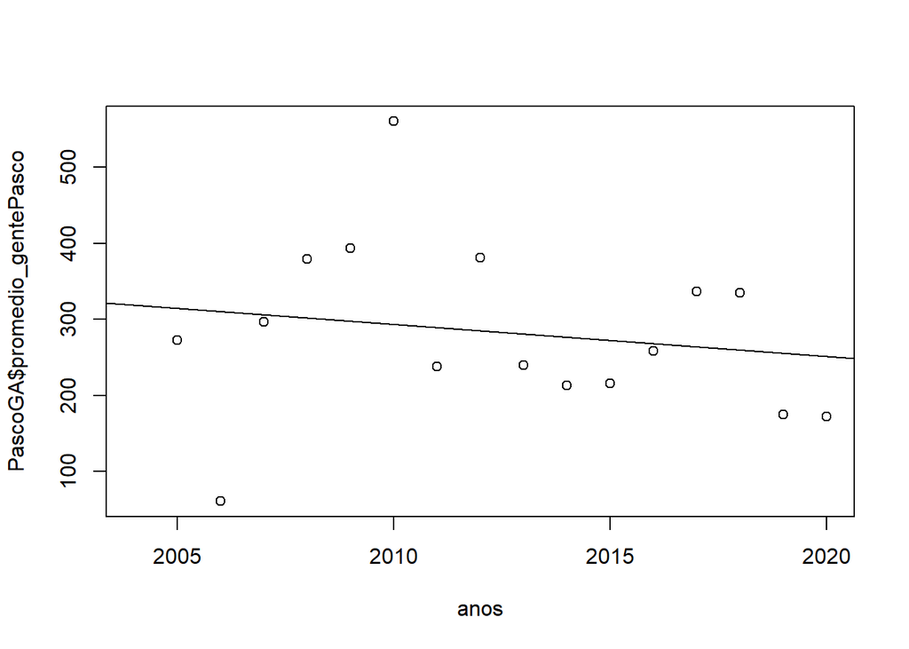

Como se puede observar para Piura, el valor-p es de $0.01$, permitiendo concluir que se rechaza la $H_0$. En base al valor de $r^2$, se puede concluir que alrededor del $36.4$% de la variabilidad del ingreso promedio mensual se puede explicar con el año de la encuesta.

```
##
## Call:
## lm(formula = promedio_gentePiura ~ anos, data = PiuraGA)
##
## Residuals:
##     Min      1Q  Median      3Q     Max
## -79.362 -20.696  -6.647  12.669 126.252
##
## Coefficients:
##              Estimate Std. Error t value Pr(>|t|)
## (Intercept) 14703.926   5159.263    2.85   0.0128 *
## anos           -7.255      2.564   -2.83   0.0134 *
## ---
## Signif. codes:  0 '***' 0.001 '**' 0.01 '*' 0.05 '.' 0.1 ' ' 1
##
## Residual standard error: 47.27 on 14 degrees of freedom
##   (1 observation deleted due to missingness)
## Multiple R-squared:  0.3639, Adjusted R-squared:  0.3185
## F-statistic: 8.009 on 1 and 14 DF,  p-value: 0.01336
```

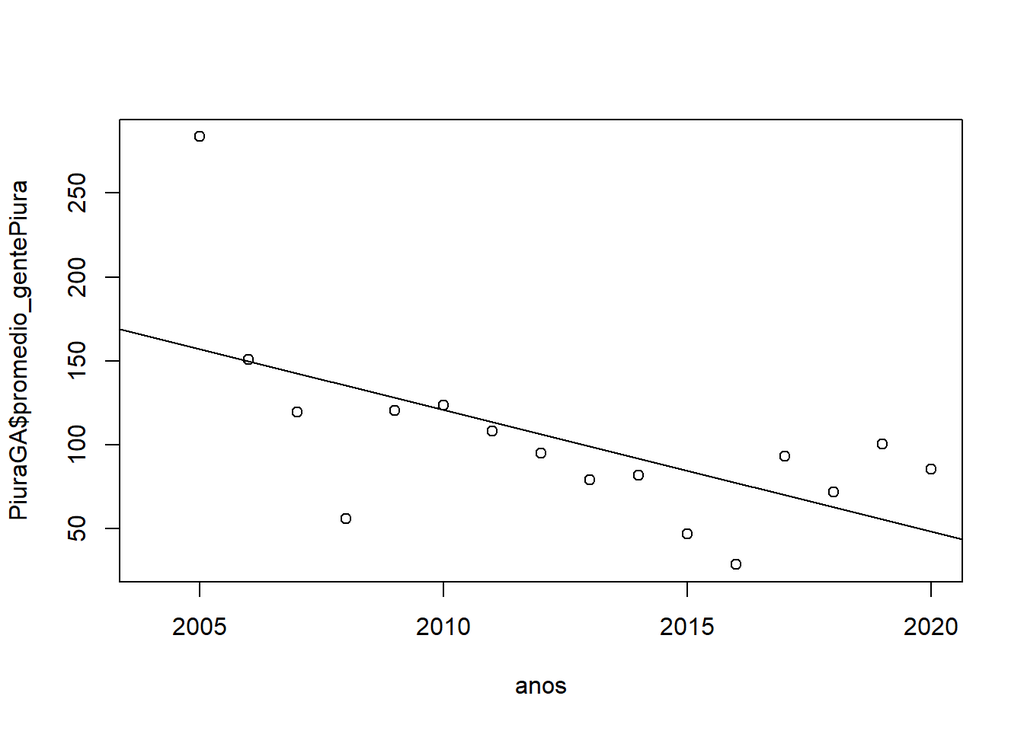

Como se puede observar para Puno, el valor-p es de $0.86$, permitiendo concluir que no se rechaza la $H_0$. En base al valor de $r^2$, se puede concluir que alrededor del $0.2$% de la variabilidad del ingreso promedio mensual se puede explicar con el año de la encuesta.

```
##
## Call:
## lm(formula = promedio_gentePuno ~ anos, data = PunoGA)
##
## Residuals:
##      Min       1Q   Median       3Q      Max
## -106.867  -22.680    2.788   30.875   85.157
##
## Coefficients:
##              Estimate Std. Error t value Pr(>|t|)
## (Intercept) 1174.6951  5587.5665    0.21    0.837
## anos          -0.4987     2.7764   -0.18    0.860
##
## Residual standard error: 51.19 on 14 degrees of freedom
##   (1 observation deleted due to missingness)
## Multiple R-squared:  0.002299,   Adjusted R-squared:  -0.06897
## F-statistic: 0.03226 on 1 and 14 DF,  p-value: 0.86
```

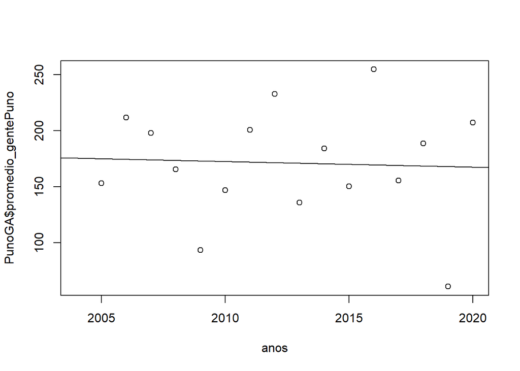

Como se puede observar para San Martin, el valor-p es de $0.69$, permitiendo concluir que no se rechaza la $H_0$. En base al valor de $r^2$, se puede concluir que alrededor del $1.1$% de la variabilidad del ingreso promedio mensual se puede explicar con el año de la encuesta.

```
##
## Call:
## lm(formula = promedio_genteSanMartin ~ anos, data = SanMartinGA)
##
## Residuals:
##    Min     1Q Median     3Q    Max
## -92.18 -38.95 -11.23  31.12 116.89
##
## Coefficients:
##              Estimate Std. Error t value Pr(>|t|)
## (Intercept) -2512.044   6554.496  -0.383    0.707
## anos            1.333      3.257   0.409    0.689
##
## Residual standard error: 60.05 on 14 degrees of freedom
##   (1 observation deleted due to missingness)
## Multiple R-squared:  0.01183,    Adjusted R-squared:  -0.05876
## F-statistic: 0.1675 on 1 and 14 DF,  p-value: 0.6885
```

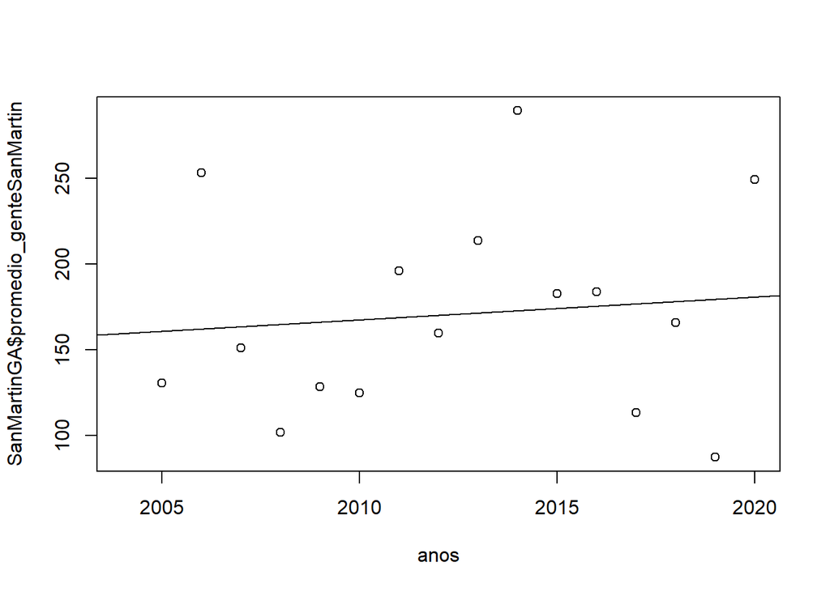

Como se puede observar para Tacna, el valor-p es de $0.29$, permitiendo concluir que no se rechaza la $H_0$. En base al valor de $r^2$, se puede concluir que alrededor del $8$% de la variabilidad del ingreso promedio mensual se puede explicar con el año de la encuesta.

```
##
## Call:
## lm(formula = promedio_genteTacna ~ anos, data = TacnaGA)
##
## Residuals:
##     Min      1Q  Median      3Q     Max
## -202.34 -107.70  -47.56   85.06  249.25
##
## Coefficients:
##              Estimate Std. Error t value Pr(>|t|)
## (Intercept) 17710.737  15688.068   1.129    0.278
## anos           -8.623      7.795  -1.106    0.287
##
## Residual standard error: 143.7 on 14 degrees of freedom
##   (1 observation deleted due to missingness)
## Multiple R-squared:  0.08037,    Adjusted R-squared:  0.01468
## F-statistic: 1.224 on 1 and 14 DF,  p-value: 0.2873
```

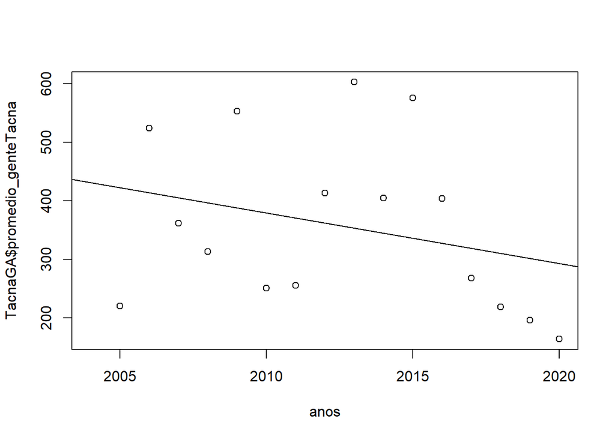

```
##
## Call:
## lm(formula = promedio_genteTumbes ~ anos, data = TumbesGA)
##
## Residuals:
##      Min       1Q   Median       3Q      Max
## -123.099  -38.259   -6.438   53.238   81.764
##
## Coefficients:
##             Estimate Std. Error t value Pr(>|t|)
## (Intercept) 4848.243   7251.100   0.669    0.515
## anos          -2.306      3.604  -0.640    0.533
##
## Residual standard error: 63.22 on 13 degrees of freedom
##   (2 observations deleted due to missingness)
## Multiple R-squared:  0.03053,    Adjusted R-squared:  -0.04405
## F-statistic: 0.4093 on 1 and 13 DF,  p-value: 0.5334
```

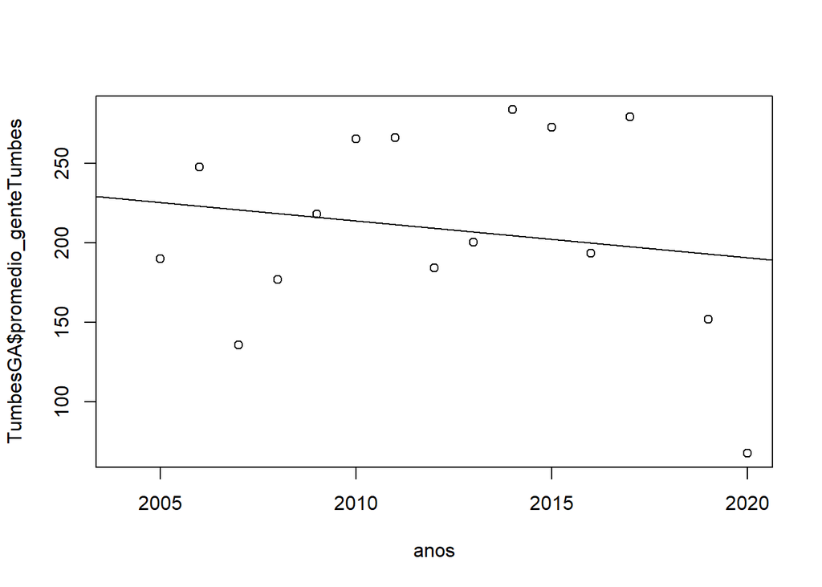

### Análisis de Regresión Gente en Misma Empresa vs Años

Para la regresión de gente trabajando en la misma empresa por región y años, no se puede concluir ninguna relación significante ya que la mayoría de regiones no rechazan la hipótesis nula de a = 0. Esto indica que conforme pasan los años, no se puede decir si el promedio de trabajadores en una misma empresa por región va aumentar o disminuir.

*TENDENCIAS Y PREDICCIONES*

*Tendencias a los largo de los años*

Tras el análisis de la gráficas de ingreso promedio anual por región, en las que se compara las variables de ingreso promedio de las regiones con el año en cuestión, notamos que tiene una tendencia a ser una funcion lineal por el ajuste de la curva.

*Predicciones de ingreso promedio anual para 2021 hasta 2025 por región*

Realizamos una función para cada región la cual predice el ingreso para esa región desde el año 2021 al 2025. Es importante recalcar que estos modelos los hemos realizado a partir de la consideración de que el crecimiento de ingresos por año se comporta de manera parecida a una recta, por lo cual utilizamos la ecuación de la recta que permite predecir los ingresos para el año 2021,2022,2023,2024,2025. Sin embargo, los valores para el modelado de la recta (a y b) se han calculado a partir de los cálculos de regresión, logrando tener a esta recta de predicción como la recta de mejor ajuste para cada región. Estos ingresos pueden variar debido a consideraciones y sucesos en el futuro que pueden impactar a la economía familiar. De igual manera, estos resultados presentan un resultado aproximado de los ingresos promedio que se podrían llegar a ver por región.

Aquí podemos ver las funciones a partir de las cuales se realizó el modelado.

Predicción para el ingreso en el 2021,2022,2023,2024 y 2025 en Amazonas

```r
predi_Am= function(año){
  y = 44.73 * año + -89398.77
  return(y)
}
predi_Am(2021:2025)
```

```
## [1] 1000.56 1045.29 1090.02 1134.75 1179.48
```

Predicción para el ingreso en el 2021,2022,2023,2024 y 2025 en Ancash

```r
predi_An= function(año){
  y = 5.452e+01  * año + -1.090e+05
  return(y)
}
predi_An(2021:2025)
```

```
## [1] 1184.92 1239.44 1293.96 1348.48 1403.00
```

Predicción para el ingreso en el 2021,2022,2023,2024 y 2025 en Apurímac

```r
predi_Ap= function(año){
  y = 48.297 * año + -96498.334
  return(y)
}
predi_Ap(2021:2025)
```

```
## [1] 1109.903 1158.200 1206.497 1254.794 1303.091
```

Predicción para el ingreso en el 2021,2022,2023,2024 y 2025 en Arequipa

```r
predi_Ar= function(año){
  y = 6.054e+01 * año + -1.209e+05
  return(y)
}
predi_Ar(2021:2025)
```

```
## [1] 1451.34 1511.88 1572.42 1632.96 1693.50
```

Predicción para el ingreso en el 2021,2022,2023,2024 y 2025 en Ayacucho

```r
predi_Ay= function(año){
  y = 43.067 * año + -85945.050
  return(y)
}
predi_Ay(2021:2025)
```

```
## [1] 1093.357 1136.424 1179.491 1222.558 1265.625
```

Predicción para el ingreso en el 2021,2022,2023,2024 y 2025 en Cajamarca

```r
predi_Ca= function(año){
  y = 47.259 * año + -94368.924
  return(y)
}
predi_Ca(2021:2025)
```

```
## [1] 1141.515 1188.774 1236.033 1283.292 1330.551
```

Predicción para el ingreso en el 2021,2022,2023,2024 y 2025 en Callao

```r
predi_Call= function(año){
  y = 6.270e+01 * año + -1.252e+05
  return(y)
}
predi_Call(2021:2025)
```

```
## [1] 1516.7 1579.4 1642.1 1704.8 1767.5
```

Predicción para el ingreso en el 2021,2022,2023,2024 y 2025 en Cusco

```r
predi_Cus= function(año){
  y = 6.193e+01 * año + -1.237e+05
  return(y)
}
predi_Cus(2021:2025)
```

```
## [1] 1460.53 1522.46 1584.39 1646.32 1708.25
```

Predicción para el ingreso en el 2021,2022,2023,2024 y 2025 en Huancavelica

```r
predi_Hua= function(año){
  y = 24.86 * año + -49225.06
  return(y)
}
predi_Hua(2021:2025)
```

```
## [1] 1017.00 1041.86 1066.72 1091.58 1116.44
```

Predicción para el ingreso en el 2021,2022,2023,2024 y 2025 en Huánuco

```r
predi_Huan= function(año){
  y = 5.051e+01 * año + -1.009e+05
  return(y)
}
predi_Huan(2021:2025)
```

```
## [1] 1180.71 1231.22 1281.73 1332.24 1382.75
```

Predicción para el ingreso en el 2021,2022,2023,2024 y 2025 en Ica

```r
predi_Ica= function(año){
  y = 46.152 * año + -92200.960
  return(y)
}
predi_Ica(2021:2025)
```

```
## [1] 1072.232 1118.384 1164.536 1210.688 1256.840
```

Predicción para el ingreso en el 2021,2022,2023,2024 y 2025 en Junín

```r
predi_Ju= function(año){
  y = 44.644 * año + -89064.395
  return(y)
}
predi_Ju(2021:2025)
```

```
## [1] 1161.129 1205.773 1250.417 1295.061 1339.705
```

Predicción para el ingreso en el 2021,2022,2023,2024 y 2025 en La Libertad

```r
predi_Lali= function(año){
  y = 44.990 * año + -89814.615
  return(y)
}
predi_Lali(2021:2025)
```

```
## [1] 1110.175 1155.165 1200.155 1245.145 1290.135
```

Predicción para el ingreso en el 2021,2022,2023,2024 y 2025 en Lambayeque

```r
predi_Lam= function(año){
  y = 46.283 * año + -92469.298
  return(y)
}
predi_Lam(2021:2025)
```

```
## [1] 1068.645 1114.928 1161.211 1207.494 1253.777
```

Predicción para el ingreso en el 2021,2022,2023,2024 y 2025 en Lima

```r
predi_Li= function(año){
  y = 73.62 * año -147087.26
  return(y)
}
predi_Li(2021:2025)
```

```
## [1] 1698.76 1772.38 1846.00 1919.62 1993.24
```

Predicción para el ingreso en el 2021,2022,2023,2024 y 2025 en Loreto

```r
predi_Lor= function(año){
  y =  71.29  * año + -142574.05
  return(y)
}
predi_Lor(2021:2025)
```

```
## [1] 1503.04 1574.33 1645.62 1716.91 1788.20
```

Predicción para el ingreso en el 2021,2022,2023,2024 y 2025 en Madre de Dios

```r
predi_MaD= function(año){
  y = 43.84 * año + -87244.17
  return(y)
}
predi_MaD(2021:2025)
```

```
## [1] 1356.47 1400.31 1444.15 1487.99 1531.83
```

Predicción para el ingreso en el 2021,2022,2023,2024 y 2025 en Moquegua

```r
predi_Moq= function(año){
  y = 78.08 * año + -155815.55
  return(y)
}
predi_Moq(2021:2025)
```

```
## [1] 1984.13 2062.21 2140.29 2218.37 2296.45
```

Predicción para el ingreso en el 2021,2022,2023,2024 y 2025 en Pasco

```r
predi_Pas= function(año){
  y = 37.18 * año + -73912.19
  return(y)
}
predi_Pas(2021:2025)
```

```
## [1] 1228.59 1265.77 1302.95 1340.13 1377.31
```

Predicción para el ingreso en el 2021,2022,2023,2024 y 2025 en Piura

```r
predi_Piu= function(año){
  y = 46.86 * año + -93627.39
  return(y)
}
predi_Piu(2021:2025)
```

```
## [1] 1076.67 1123.53 1170.39 1217.25 1264.11
```

Predicción para el ingreso en el 2021,2022,2023,2024 y 2025 en Puno

```r
predi_Pun= function(año){
  y = 35.99 * año + -71741.46
  return(y)
}
predi_Pun(2021:2025)
```

```
## [1]  994.33 1030.32 1066.31 1102.30 1138.29
```

Predicción para el ingreso en el 2021,2022,2023,2024 y 2025 en San Martín

```r
predi_SaM= function(año){
  y = 45.19 * año + -90207.14
  return(y)
}
predi_SaM(2021:2025)
```

```
## [1] 1121.85 1167.04 1212.23 1257.42 1302.61
```

Predicción para el ingreso en el 2021,2022,2023,2024 y 2025 en Tacna

```r
predi_Tac= function(año){
  y = 60.59 * año + -120892.26
  return(y)
}
predi_Tac(2021:2025)
```

```
## [1] 1560.13 1620.72 1681.31 1741.90 1802.49
```

Predicción para el ingreso en el 2021,2022,2023,2024 y 2025 en Tumbes

```r
predi_Tum= function(año){
  y = 62.25 * año + -124443.14
  return(y)
}
predi_Tum(2021:2025)
```

[output not shown]

Predicción para el ingreso en el 2021,2022,2023,2024 y 2025 en Ucayali

```r
predi_Uca= function(año){
  y = 43.51  * año + -86858.05
  return(y)
}
predi_Uca(2021:2025)
```

```
## [1] 1075.66 1119.17 1162.68 1206.19 1249.70
```

MODELOS DE PREDICCIÓN

Modelo de predicción Amazonas

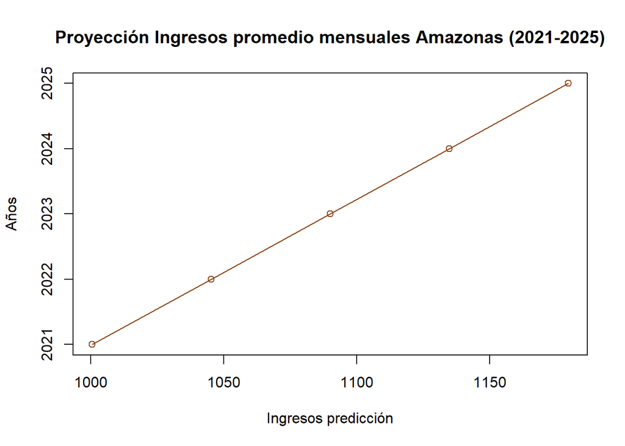

Modelo de predicción Ancash

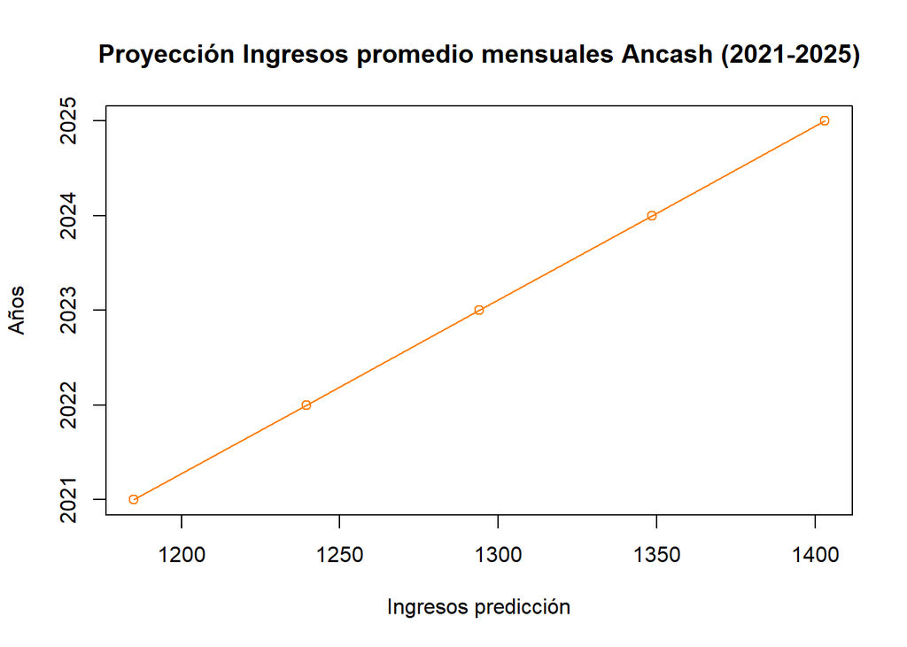

Modelo de predicción Apurímac

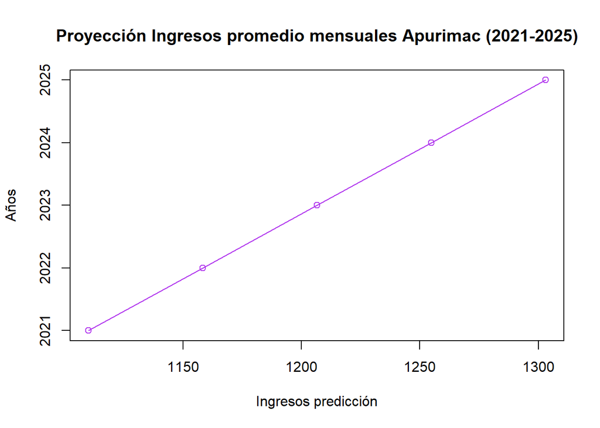

Modelo de predicción Arequipa

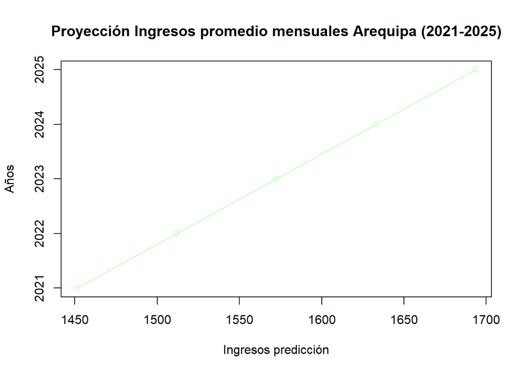

Modelo de predicción Ayacucho

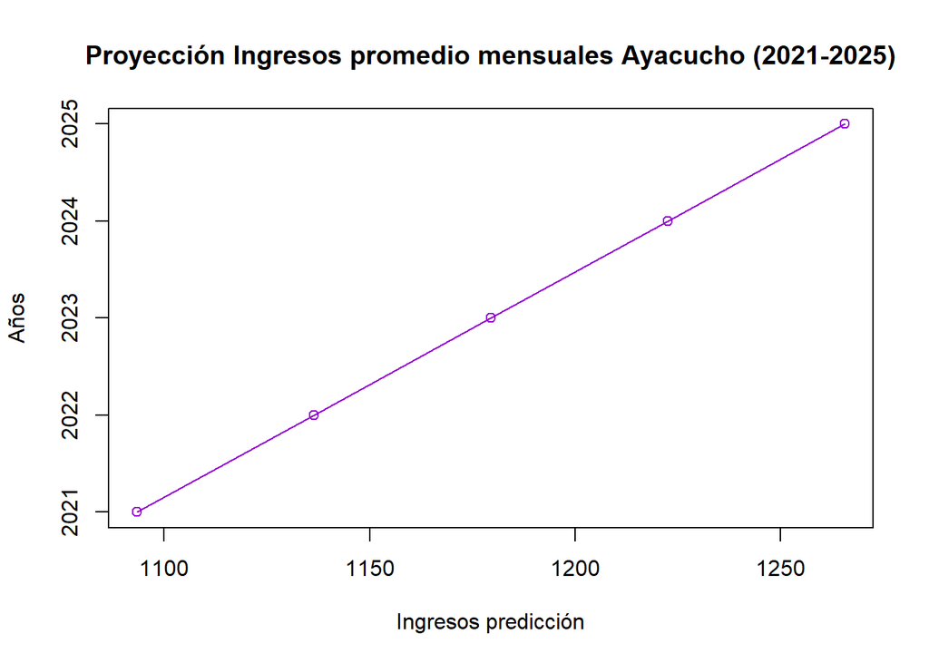

Modelo de predicción Cajamarca

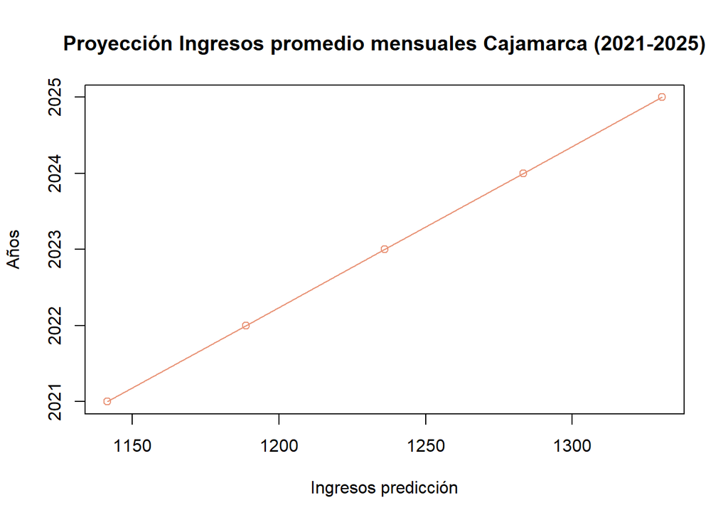

Modelo de predicción Callao

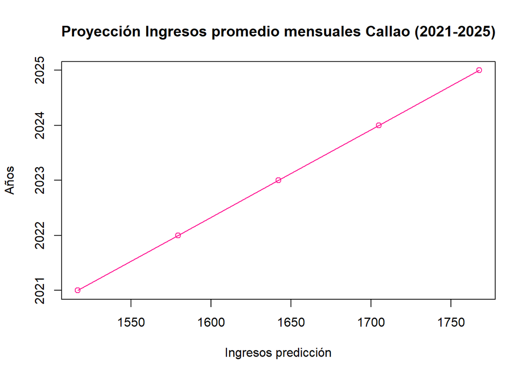

Modelo de predicción Cuzco

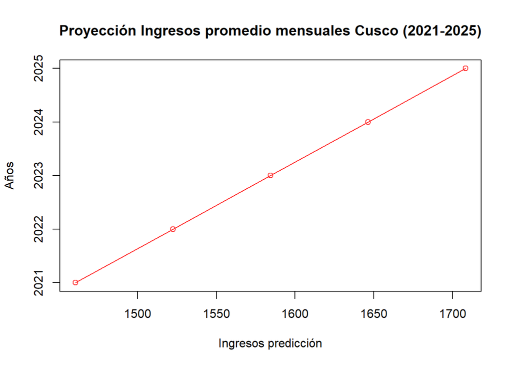

Modelo de predicción Huancavelica

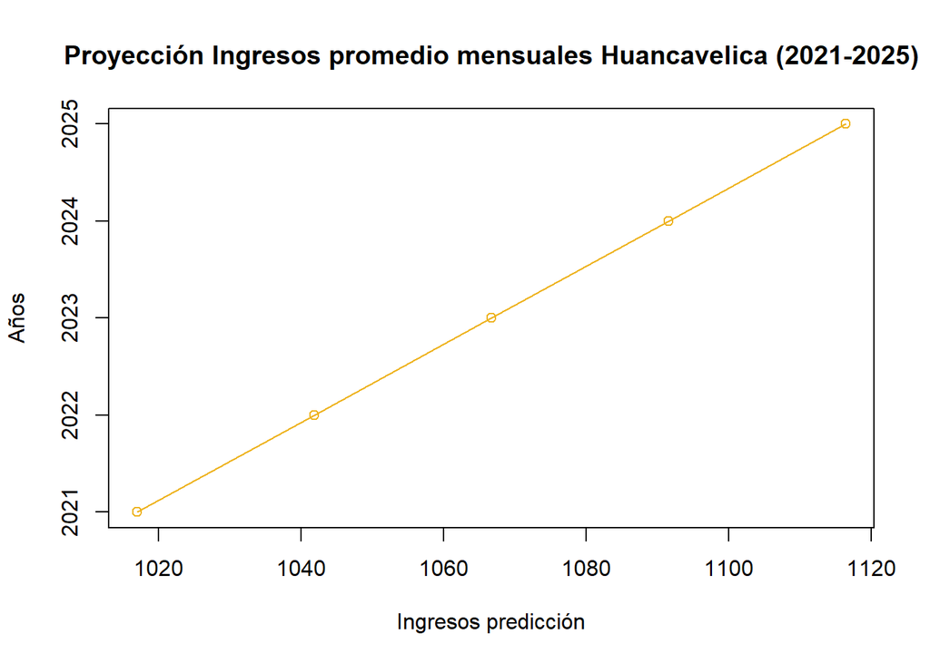

Modelo de predicción Huánuco

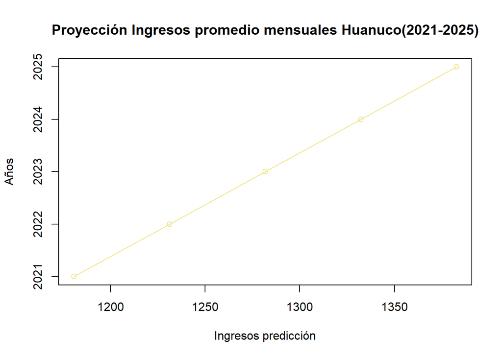

Modelo de predicción Ica